# Capital, Labour and Justice

Lecture 5: Redistribution

Dr David Chivers

Political Economy

## What is inequality?

## Inequality of what?

- Income, wealth, consumption?
- Within or between countries, groups or generations?
- Relative or absolute?
- Inequality of opportunity or outcome?
- What measure e.g. Range, Gini coefficient or Top 1%?

## Inequality

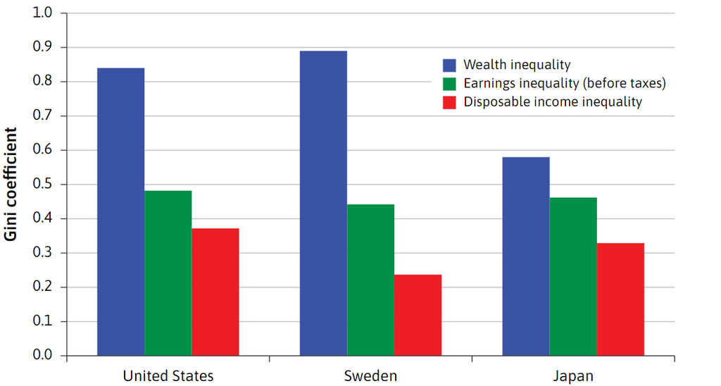

## Wealth Inequality

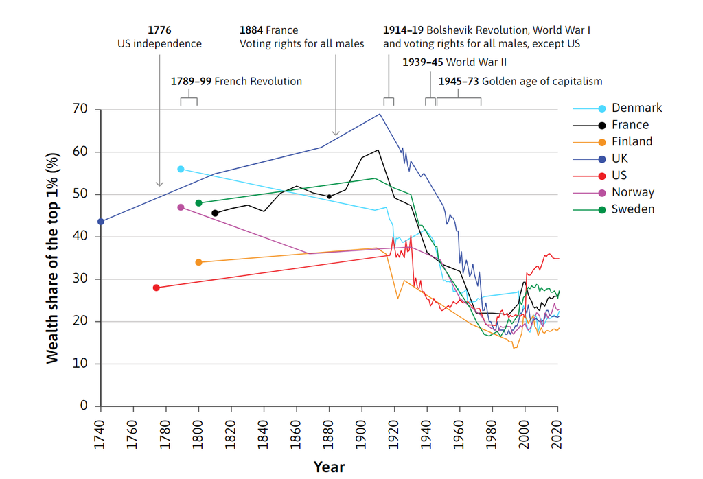

## Types of Income

- **Market income** is the sum of…
- all income received as earnings (wages, self-employment)
- all income received from business owned by the household or from investments
- **Disposable income** is the income that a family can spend
- after paying taxes
- after receiving any monetary transfers from the government (e.g. unemployment benefit and pensions)
- **Final Income:** is the income that a family can spend
- Subtract VAT paid.
- Add the value of public services received.

## Income Types

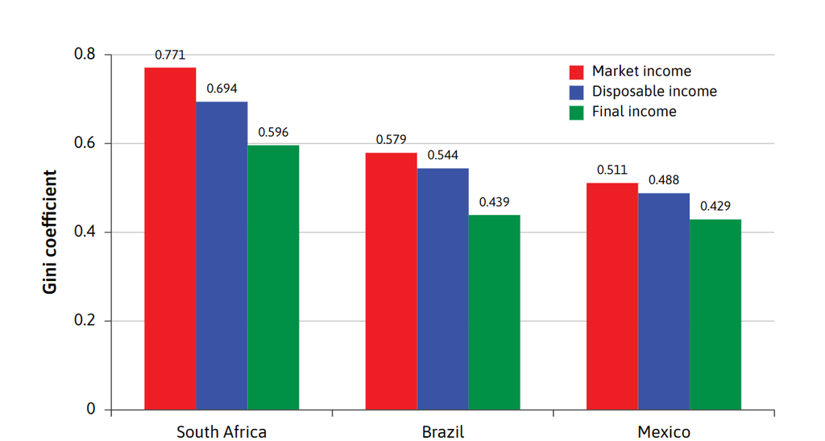

## Types of Income

### Countries that tend to reduce inequality do so via transfers rather than taxes:

- Much of this justified for reasons other than redistributing income.
- Social insurance, for example, is seen as redistributing from the lucky to the unlucky

### Let’s look at the average Ginis within the EU in 2015

- The Gini for market income is 0.46
- The Gini for disposable income is 0.27
- But taxes only achieve 0.04 of that redistribution
- The remaining 0.15 driven is by transfers to households.
- Note: this does not mean the EU has low tax rates, but instead it means that rich and poor pay similar shares of their incomes in taxes.
- On the other hand, poorer households benefit proportionally from expenditures.

## Measures of Inequality

## Relative vs Absolute

- **Absolute inequality** is a difference measure
- **Relative inequality** is a ratio measure.
- Let’s say two incomes £ 10,000 & £50,000 increase to £100,000 and £ 500,000, respectively
- Absolute inequality gains as the difference moves from £40,000 to £ 400,000
- Relative inequality remains at 1:5
- Although absolute measures are important to pay attention to, most inequality measures are relative

## Absolute Redistribution

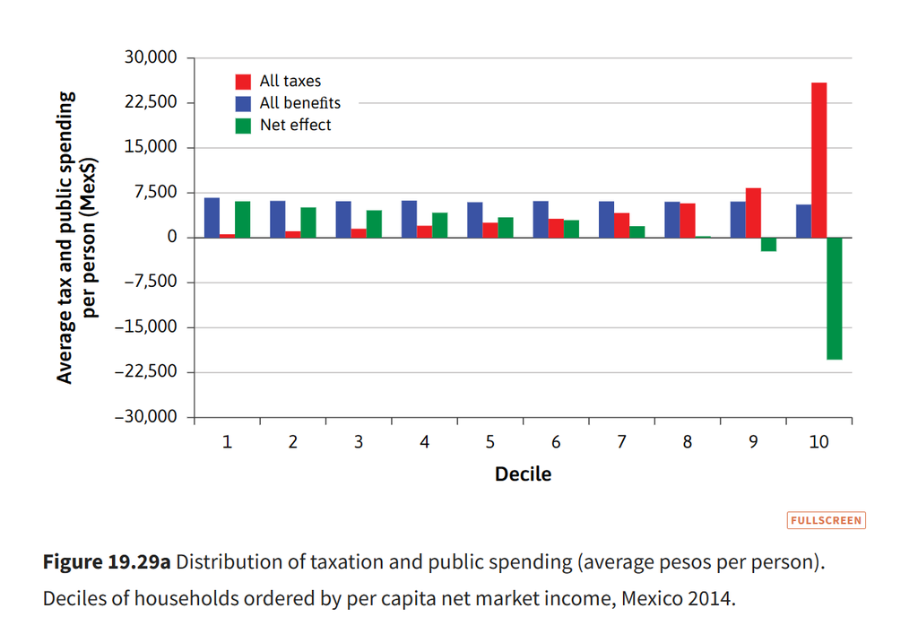

## Relative Redistribution

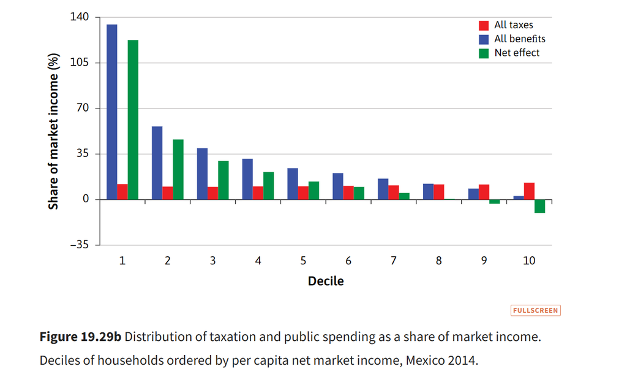

## The Gini Coefficient

- The most widely used measure of inequality is the Gini coefficient
- The Gini coefficient is usually used to measure of income inequality,
- However, but it can be used to measure the any forms of inequality (e.g. consumption or life expectancy)
- The scale is from 0 to 1
- The higher the value, the higher the level of inequality.
- A value of 0 would mean perfect equality – everyone has the same income.
- A value of 1 would mean perfect inequality – one person received all the income
- The Gini coefficient is more sensitive around the middle of the distribution than at the top or bottom compared to other measures of inequality

## Method 1: The Gap

- The Gini coefficient is the expected absolute gap between people’s incomes relative to mean income
- It is the gap we would expect if two people in the population met randomly
- We can calculate it by taking the average gap between all pairs of people.
- Specifically, we calculate it as the expected gap as a share of twice the mean income.
- Twice the mean income is equal to perfect inequality. Why?
- Suppose our economy is just two people and that their total income is £100.
- Their average income is £50 (£100/2).
- Under perfect inequality one person has £100 and the other £0
- The gap between them will be £100… twice the mean income.

## Method 2: Lorenz curve

- If income is shared perfectly equally, the Lorenz curve would be a straight line
- In the graph, the bottom 60% of the population earns 30% of the total income.
- The Gini coefficient captures how far the Lorenz curve falls from the ‘line of equality’ by comparing the areas A and B

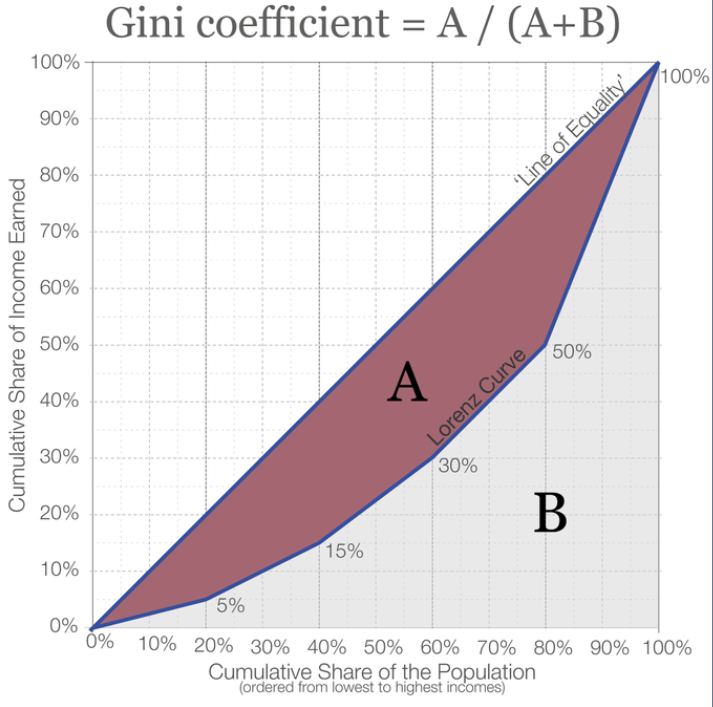

## Value Judgements

- Measures of inequality have value judgements implicitly built into them (Atkinson, 1970)
- Which society has the greater levels of inequality?
- **Society 1:** The rich are much richer than those in the middle, but poor people have incomes just below those with middle incomes
- **Society 2:** The rich are just above those with middle incomes, but the poor are much poorer than those with middle incomes.
- Your answer will depend on how you view these gaps in different parts of the distribution and how they compare in terms of the contribution they make to inequality.

## Comparing Measures

[figure not shown]

## Gini and Taxes

[figure not shown]

## Redistribution

## Pre-distribution

- **Before and** **after-tax** **income does not tell us the** **total reduction of inequality** **caused** **by redistribution**
- Taxes and benefits will have an effect on income before income has even been taxed
- For example, you may decide not to work longer hours if you move to a higher tax bracket

### This can make cross-country comparisons difficult

- Public pensions are counted as redistribution, whereas private pensions are not.
- Countries where public pensions are higher will likely see lower wages
- But if there was no public pension scheme, we would expect those countries to receive higher wages.
- CEOs bargain for more money, increasing pre-tax wage inequality (Piketty, Saez, and Stancheva, 2014)

## Redistribution

### Indirect taxes

- Indirect taxes, such as consumption taxes (e.g. V.A.T) are not accounted for in redistribution measures
- Poorer people, on average, spend a higher share of their income
- Some say consumption taxes increase inequality as a result, but this is debateable (see next slide)

### Government Spending:

- Government cash transfers are not only way government spends money (e.g. education & public parks)
- This type of government spending may benefit poorer people more but is difficult to measure

### Two types of taxation:

- **Progressive taxation:** When the direct effect of a tax or transfer policy (compared to what would happen in the absence of the policy) gives a reduction in inequality
- **Regressive taxation:** If a policy’s direct effect causes a rise in inequality

## Regressive or Progressive?

- For an expenditure or transfer to be progressive, it must increase the incomes of poorer households by more than richer households, in relative terms.
- This guarantees that it will reduce the Gini coefficient
- Note that this policy might mean that in absolute terms, the richer households are receiving more

### Is V.A.T. Regressive or Progressive?

- V.A.T. is complex as it effects savings behaviour (Thomas, 2020)
- Income that is saved will eventually be taxed by V.A.T. when it is consumed
- We can remove savings behaviour by measuring it relative to current income or expenditure
- It appears to be regressive if measured as a proportion of current income
- It appears to be progressive if measured percentage of current expenditure

## Wealth Taxes

- There are two main disagreements among economist about annual wealth tax
- Difficulty in implementation
- Even if perfectly implemented, is it the right tool to achieve policy objective?
- Imagine wealth of £100 gives capital income of £5 a year.
- A 1% wealth tax is the same as a 20% capital income tax…£1
- Imagine now wealth returned an excess capital income of £20 a year
- A 1% wealth tax would return £1 but a capital income tax £4
- There are strong arguments in favour of taxing excess returns over normal returns
- Wealth taxes, however, do the opposite
- If all income from work and all excess returns to capital were taxed (including inheritance tax) would there need to be a wealth tax?

## Wealth Taxes

- Three “principled rationales” for wealth taxes (IFS, 2021)

### A wealth tax in order to tax savers

- Some people are better at saving than others (e.g. have higher financial literacy)
- “Use it of lose it”: tax normal returns more than excess as it rewards (and encourages) entrepreneurial activity (Guvenen et al., 2019)

### A wealth tax when wealth has benefits beyond purchasing power

- If wealth has benefits to the wealth-holder more than the consumption it can be derived from
- Although this is debatable – perhaps they simply have not found the thing to spend it on.

### A wealth tax when wealth has negative externalities

- If wealth confers status, and status is a zero-sum game – it is relative position that matters
- If wealth is harmful to others (although would have to be contingent on not spending the wealth)

## Summary

- We need to be specific about what type of inequality we mean
- It is difficult to separate inequality measures from value judgements
- Comparing redistribution across countries is hard because of pre-distribution
- The extent to which wealth taxes are implementable or desirable is debateable
- See [Talis](https://durham.rl.talis.com/modules/econ2301.html) for **reading list**.

Note: not all citations in this lecture are listed there.